# Untitled

## Environment and data set up

The below code chunk loads the requisite libraries for this analysis.

```r
library(tidyverse)
library(tidymodels)
cars <- readxl::read_excel("data/kellycarsalesdata.xlsx") %>%
  janitor::clean_names()
```

Using `rsample` I partition my data.

```r
init_split <- initial_split(cars)
car_train <- training(init_split)
car_testing <- testing(init_split)
```

## 3. Outliers

```r
skimr::skim(cars)
```

```
## Skim summary statistics
##  n obs: 804
##  n variables: 9
##
## ── Variable type:character ───────────────────────────────────────────────────────────────────────────────────────────
##  variable missing complete   n min max empty n_unique
##      make       0      804 804   4   9     0        6
##
## ── Variable type:numeric ─────────────────────────────────────────────────────────────────────────────────────────────
##  variable missing complete   n     mean      sd      p0      p25     p50
##    cruise       0      804 804     0.75    0.43    0        1        1
##  cylinder       0      804 804     5.27    1.39    4        4        6
##     doors       0      804 804     3.53    0.85    2        4        4
##   leather       0      804 804     0.72    0.45    0        0        1
##     liter       0      804 804     3.04    1.11    1.6      2.2      2.8
##   mileage       0      804 804 19831.93 8196.32  266    14623.5  20913.5
##     price       0      804 804 21343.14 9884.85 8638.93 14273.07 18025
##     sound       0      804 804     0.68    0.47    0        0        1
##       p75     p100     hist
##      1        1    ▂▁▁▁▁▁▁▇
##      6        8    ▇▁▁▆▁▁▁▂
##      4        4    ▂▁▁▁▁▁▁▇
##      1        1    ▃▁▁▁▁▁▁▇
##      3.8      6    ▅▇▁▇▁▂▁▁
##  25213    50387    ▂▃▅▇▅▁▁▁
##  26717.32 70755.47 ▇▆▃▂▁▁▁▁
##      1        1    ▃▁▁▁▁▁▁▇
```

Upon looking at the distributions of the numeric variables, I feel confident in that there are no true outliers. Perhaps we can identify a few in `price`, but dollar values are always heavily right skewed and this is a fact of wealth accumulations and pricing. Perhaps we can find a few values that exceed the 1.5 IQR ranges. To check, I will use the `anomalize` package by Matt Dancho of Business Science University to check both the mileage and the price columns as these are our only continuous variables.

```r
# outliers where? in every single column?
# no outliers in mileage
anomalize::anomalize(cars, mileage) %>%
  count(anomaly)
```

```
## # A tibble: 1 x 2
##   anomaly     n
##   <chr>   <int>
## 1 No        804
```

```r
# 5 outliers of price using iqr
anomalize::anomalize(cars, price) %>%
  count(anomaly)
```

```
## # A tibble: 2 x 2
##   anomaly     n
##   <chr>   <int>
## 1 No        799
## 2 Yes         5
```

I will create a tibble containing the original data less the 5 observations that are deemed anomalies via IQR method. We could also use the GESD Method, but this is computational intensive and unnecessary at the moment.

```r
cars_no_anomaly <- anomalize::anomalize(cars, price) %>%
  filter(anomaly == "No") %>%
  select(-anomaly, -price_l1, -price_l2)
```

## 4. Distributions

The distributions were visualized with `skimr::skim()` previously. The only variables which are continuous are `mileage` and `price`. These two variables display characteristics of normality with a right skew. We should use a heteroskedastic robust linear regression model to deal with the inevitible heteroskedacity due to a log normal distribution in price. We can transform the variables but the skews are not heavy enough to warrant log or inverse methods. Perhaps a square root transformation would be appropriate. Before making such an adjustment I would prefer to fit the model as is.

## 5. Correlations

To create the initial correlations, I will use the `corrr` package from tidymodels.

```r
corrr::correlate(select_if(cars, is.numeric)) %>%
  corrr::focus(price) %>%
  arrange(-abs(price))
```

```
##
## Correlation method: 'pearson'
## Missing treated using: 'pairwise.complete.obs'
```

```
## # A tibble: 7 x 2
##   rowname   price
##   <chr>     <dbl>
## 1 cylinder  0.569
## 2 liter     0.558
## 3 cruise    0.431
## 4 leather   0.157
## 5 mileage  -0.143
## 6 doors    -0.139
## 7 sound    -0.124
```

There are strong correlations between price and cylinder, and price and liter.

To visualize the correlation matrix, I will use `corrplot`. First, I select only the numeric variables from the tibble, create a correlation matrix, and then create a correlation plot.

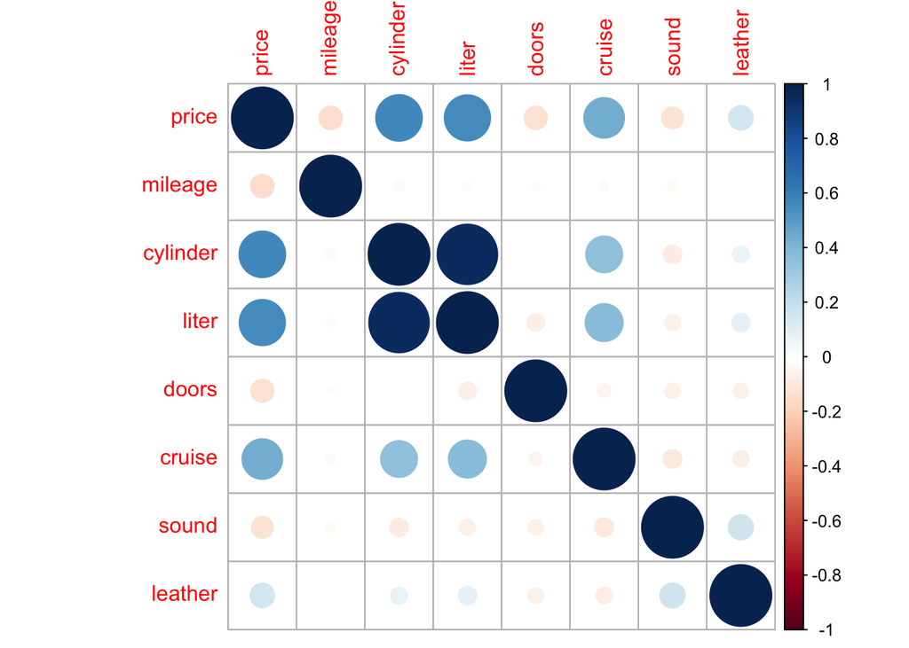

```r
select_if(cars, is.numeric) %>%
  cor() %>%
  corrplot::corrplot()
```

Given the above plot there is a high amount of colinearity between liter and cylinder. One of these variables should likely be omitted.

## 6. Fitting a regression

This question requests principle components but there is no instruction to perform PCA, as such, I will not do that. I will use the `estimatr` package to fit a linear regression.

```r
lm_1 <- estimatr::lm_robust(price ~ ., data = car_train)

lm_1 %>%
  broom::tidy() %>%
  knitr::kable(digits = 3)
```

| term | estimate | std.error | statistic | p.value | conf.low | conf.high | df | outcome |
| --- | --- | --- | --- | --- | --- | --- | --- | --- |
| (Intercept) | 15757.037 | 1132.164 | 13.918 | 0.000 | 13533.474 | 17980.600 | 590 | price |
| mileage | -0.184 | 0.023 | -8.094 | 0.000 | -0.229 | -0.139 | 590 | price |
| makeCadillac | 15715.379 | 756.122 | 20.784 | 0.000 | 14230.360 | 17200.397 | 590 | price |
| makeChevrolet | -2154.243 | 419.299 | -5.138 | 0.000 | -2977.744 | -1330.742 | 590 | price |
| makePontiac | -1556.524 | 389.933 | -3.992 | 0.000 | -2322.349 | -790.699 | 590 | price |
| makeSAAB | 14737.764 | 455.527 | 32.353 | 0.000 | 13843.113 | 15632.414 | 590 | price |
| makeSaturn | -2288.150 | 410.980 | -5.568 | 0.000 | -3095.313 | -1480.987 | 590 | price |
| cylinder | -383.267 | 534.316 | -0.717 | 0.473 | -1432.660 | 666.126 | 590 | price |
| liter | 4871.133 | 650.425 | 7.489 | 0.000 | 3593.703 | 6148.563 | 590 | price |
| doors | -1552.587 | 310.539 | -5.000 | 0.000 | -2162.483 | -942.691 | 590 | price |
| cruise | -557.265 | 288.876 | -1.929 | 0.054 | -1124.614 | 10.085 | 590 | price |
| sound | -166.372 | 319.616 | -0.521 | 0.603 | -794.096 | 461.352 | 590 | price |
| leather | 29.195 | 251.674 | 0.116 | 0.908 | -465.090 | 523.480 | 590 | price |

```r
broom::glance(lm_1) %>%
  knitr::kable(digits = 3)
```

| r.squared | adj.r.squared | statistic | p.value | df.residual | N | se_type |
| --- | --- | --- | --- | --- | --- | --- |
| 0.874 | 0.872 | 468.312 | 0 | 590 | 603 | HC2 |

## 7 variable selection by p-value

We should not curate our linear models to only include “statistically significant” variables. This ruins the interprative powers of a linear regression. However, I will do so as these are the instructions.

```r
lm_2 <- estimatr::lm_robust(price ~ mileage + make + cylinder + liter + doors + cruise + sound, data = car_train)
lm_3 <- estimatr::lm_robust(price ~ mileage + make + liter + doors + cruise + sound, data = car_train)
lm_4 <- estimatr::lm_robust(price ~ mileage + make + liter + doors + sound, data = car_train)
lm_final <- estimatr::lm_robust(price ~ mileage + make + liter + doors, data = car_train)
```

```r
broom::tidy(lm_final) %>%
  knitr::kable(digits = 3)
```

| term | estimate | std.error | statistic | p.value | conf.low | conf.high | df | outcome |
| --- | --- | --- | --- | --- | --- | --- | --- | --- |
| (Intercept) | 14584.423 | 1551.713 | 9.399 | 0 | 11536.910 | 17631.935 | 594 | price |
| mileage | -0.183 | 0.023 | -7.982 | 0 | -0.228 | -0.138 | 594 | price |
| makeCadillac | 15519.266 | 1008.764 | 15.384 | 0 | 13538.088 | 17500.445 | 594 | price |
| makeChevrolet | -1946.676 | 411.722 | -4.728 | 0 | -2755.283 | -1138.069 | 594 | price |
| makePontiac | -1404.796 | 397.674 | -3.533 | 0 | -2185.814 | -623.777 | 594 | price |
| makeSAAB | 14792.882 | 481.059 | 30.751 | 0 | 13848.098 | 15737.665 | 594 | price |
| makeSaturn | -1903.751 | 446.576 | -4.263 | 0 | -2780.811 | -1026.692 | 594 | price |
| liter | 4381.266 | 201.902 | 21.700 | 0 | 3984.737 | 4777.796 | 594 | price |
| doors | -1555.487 | 277.860 | -5.598 | 0 | -2101.195 | -1009.780 | 594 | price |

```r
broom::glance(lm_final)
```

```
##   r.squared adj.r.squared statistic       p.value df.residual   N se_type
## 1  0.873524     0.8718206  636.7357 1.258429e-285         594 603     HC2
```

This final model performs as well as the original one. Now, if we are after performance and not inference, this is a completely fine conclusion.

We find that, like the original model, the make of a car has the biggest impact on the value of a car. Now that we have removed some variables—such as cylinders—other variables will be compensating for the variance that is explained by them. For example we know that cylinders and liters are highly correlated—though not completely—so liters is likely taking on a bit of the explanatory power of cylinders.

## 9.

The inclusion of year is misleading as this is not included in the dataset.

```r
test_val <- tibble(
  doors = 4,
  make = "SAAB",
  mileage = 61435,
  cruise = 1,
  cylinder = 4,
  liter = 2.3,
  sound = 1,
  leather = 1
)

estimatr:::predict.lm_robust(lm_1, test_val, interval = "confidence")
```

```
## $fit
##           fit      lwr      upr
## [1,] 21953.15 19895.01 24011.29
```

```r
estimatr:::predict.lm_robust(lm_final, test_val, interval = "confidence")
```

```
## $fit
##           fit      lwr      upr
## [1,] 21984.74 19924.92 24044.55
```

The predictions for our example SAAB car are *very* similar. However, due to the inclusion of different variables, we are returned very slightly different prediction intervals.